# Opportunity Costs

Ernesto Carrella

September 25, 2015

This demo is a bit longer and a bit more rambling than usual.  
I think it’s a nice time to show how the model’s subsystems counteract one another.

The basic setup is as follows: there are 2 species of fish in the world. Red fishes are protected by quotas while blue ones aren’t. To make things simpler, the red fishes live north, the blue south and they do not share any habitat.

[figure not shown]

Now here’s where things get complicated. If reds are protected by an ITQ and the blues aren’t, ideally you’d like to catch only blues and sell all your red quotas. On the other hand if everybody thinks like this and avoid reds then red quotas are worthless. But if the quotas are worthless then there is no point in catching only blues.  
So there is a simple tradeoff here: the higher the quota prices the more you’d like to fish blue, but the more you fish blue the lower the quota prices get.

In a nice economic model that tradeoff would generate a simple quota price equilibrium and that would be it: there’d be an optimal proportion of catches for blues and reds.  
Unfortunately in our model things get much messier.  
Firstly, if the proportion of red and blue catches isn’t equal then over time the overfished specie (blues probably) would get rarer and rarer changing the equilibrium proportion and quota prices.  
Second, because our agents aren’t gods they can’t just will the right proportion of blue to red catches to just happen there will be exploration noise which in turn will put pressure on the biomass in a “non-optimal” way further changing equilibrium proportion and quota prices.

So because a lot of things are interacting with one another, let’s turn everything off and endogenize one thing at a time.

# Exogenous Quota Prices

## Fixed biomass

This is the simplest example.  
Fishers catches do not affect the stock of fish and quota prices are manipulated by me from the outside rather than being generated by expectations as is [usually the case](http://carrknight.github.io/assets/oxfish/lambda.html). Here the agents just need to react to exogenous quota prices: if the quota prices are high then they prefer to catch blue, if the quota prices are 0, they ought to be indifferent, if the quota prices are negative (maybe there is a reward for catching reds) then they’d prefer to catch red.

The fixed biology looks like this:

[figure not shown]

If I feed an wavy quota price to the agents they repeatedly switch from catching blue to catching red (and back) depending on the current quota prices:

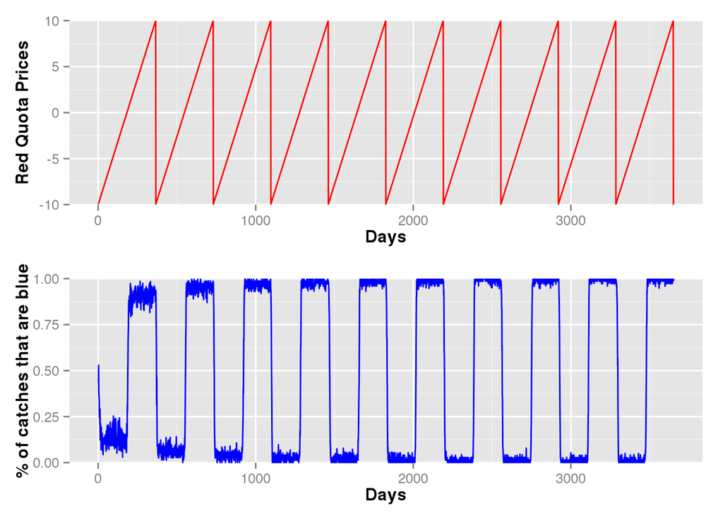

Which in motion looks like this:

[figure not shown]

The basic result is that agents react very quickly to changes in opportunity costs switching from reds to blues and back. This result is made very clear by turning off both price endogeneity (the wavy quota prices are exogenous) and environmental degradation.

## Proper Biomass

Now biomass is affected by fishing effort. Quota prices are still wavy and exogenous. The basic result still stands, you see switching occurring but within a more noisy progressive exploitation of areas close to port.

[figure not shown]

As fishers are pushed farther and farther from port and the fishing opportunities become rarer, the switching behavior becomes more sluggish (as it takes time to discover a non-consumed area of the map with the right kind of fish):

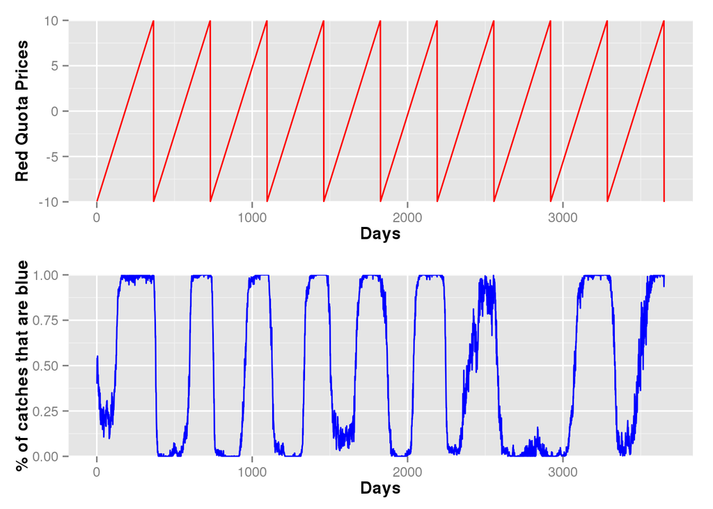

Visually you can see that after 9 years of simulation biomass is consumed almost everywhere except the edges of the map.

[figure not shown]

# Ignored Quota Prices

One thing that is important to understand is that exploration itself, even after ignoring opportunity costs, can create some “switching”. The basic idea is simple: fishers tend to imitate one another and may group in the south part of the map until they exploit it so much that one of them figure out the north part of the map is more profitable at which point everyone follows him

Exploration creates an autocorrelated noise in the catches plot that looks similar to switching due to opportunity costs. Here’s an example for a run with non-fixed biomass and no quota system; as you can see there are times when almost all or almost none of the catches is blue. This is purely due to exploration and biomass degradation:

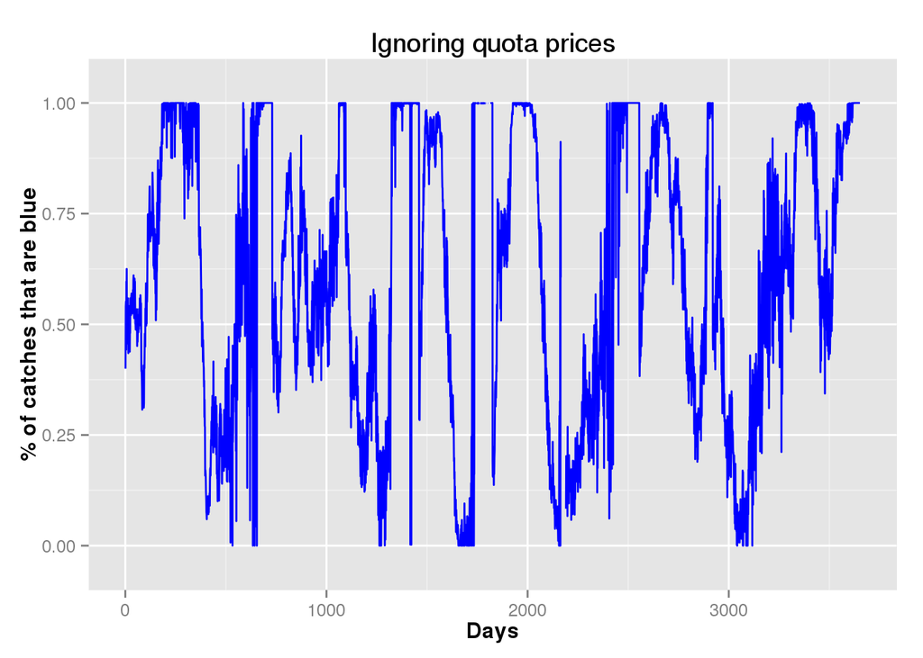

Here’s the simulation in motion. I think it’s easier to see how there is no real switching but just exploration noise and how sometimes fishers concentrate in a few spots even though there is no quota market.

[figure not shown]

In the previous section, where quota prices were fed in from the outside, exploration noise was minimized because the quota prices change were extreme. But as we move to an endogenous quota market where price swings are more moderate this exploration noise will matter more.

# All in

Now, for the full model. ITQ prices are endogenous and protect only the reds, biomass gets consumed from fishing and agents consider ITQ prices as the opportunity cost of fishing red rather than blue.

So what happens? After a brief exploratory start, agents start fishing the blues. This tanks the quota prices to the point where agents switch to the red area. This switch raises very quickly quota prices pushing back agents in the blue zone. At time quota priced and the stocks are such that agents are indifferent and spread out quite thinly.  
It is a very interesting result and somewhat of a combination of the previous runs

[figure not shown]

The time serieses show how the dynamics become more and more noisy as overfishing takes place. For the first 1000 days or so fishers quite quickly switch from red to blue and viceversa as ITQ prices move. But as blues become rarer and rarer fishers are not as able to switch and end up fishing reds even when the quota prices are high.

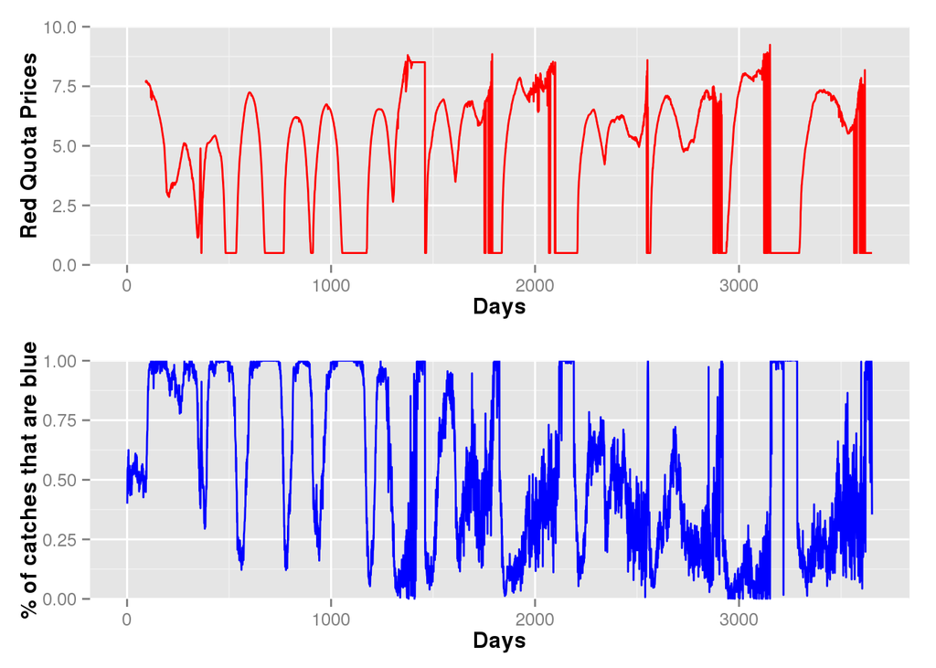